# Drilling for Data Literacy

10/22/2020

## GAP Analytics: Core Philosophy

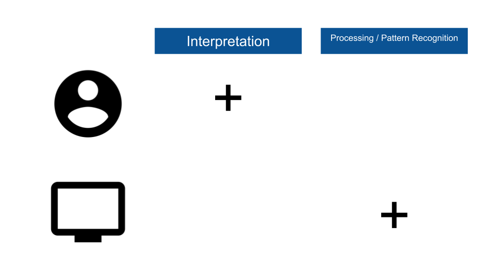

## GAP Analytics: Core Philosophy

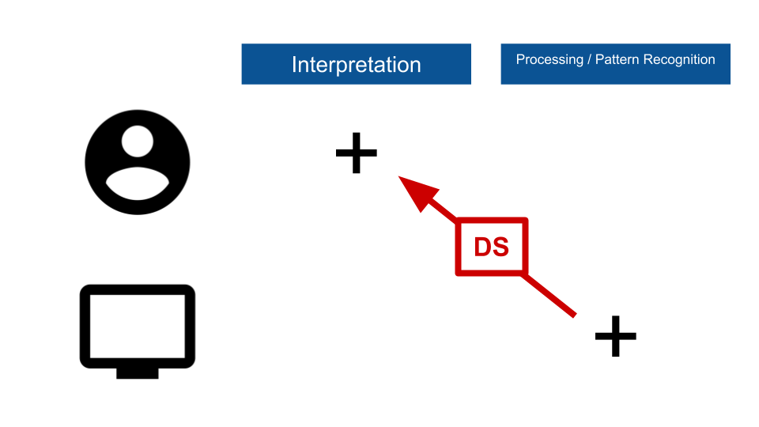

### Goal: Maximize the time analysts spend interpreting patterns that matter

## Drilling for Data Literacy

UNCLASSIFIED

UNCLASSIFIED

“Data in the 21st Century is like Oil in the 18th Century: an immensely, untapped valuable asset. Like oil, for those who see Data’s fundamental value and learn to extract and use it there will be huge rewards.”

[“Data is the New Oil”](https://www.wired.com/insights/2014/07/data-new-oil-digital-economy/)

**Joris Toonders**, WIRED 2014

“More often than not, companies are not ready for AI. Maybe they hired their first data scientist to less-than-stellar outcomes, or maybe data literacy is not central to their culture. But the most common scenario is that they have not yet built the infrastructure to implement (and reap the benefits of) the most basic data science algorithms and operations, much less machine learning.”

[“The AI Hierarchy of Needs”](https://medium.com/hackernoon/the-ai-hierarchy-of-needs-18f111fcc007)

**Monica Rogati**, Medium 2017

### **Data literacy** is the ability to read, understand, create, and communicate data as information. Data literacy focuses on the competencies involved in working with data.

## Drilling for Data Literacy

UNCLASSIFIED

UNCLASSIFIED

### **Depth** analagous to **data literacy**

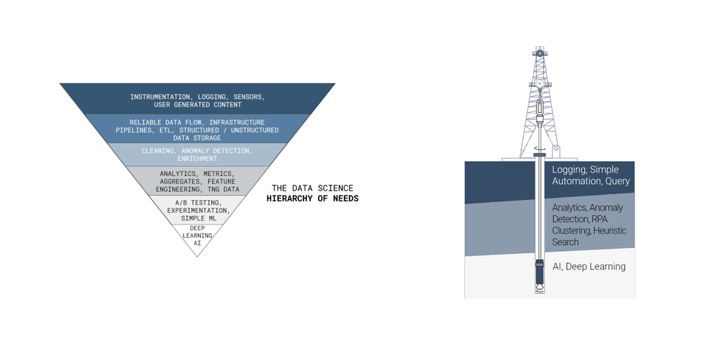

## Goal 1: Generate RPM

UNCLASSIFIED

UNCLASSIFIED

### Rotation

- an **iteration** of an analytic pipeline development cycle concluding with **end-user feedback**

### Outcomes

- mission impact
- improved digital literacy

### Takeaway: Each rotation increases torque

## Goal 2: Train for Torque

UNCLASSIFIED

UNCLASSIFIED

### Torque

- the organization’s ability to employ new **methods** and **technologies** for **mission impact**

### Key Components

- Operational Understanding (Intelligence Professional)
- Methodological Breadth (Data Scientist)
- DevSecOps (Sofware Developer)

### Outcomes

- more responsive, relevant, rigorous, and reusable workflows
- improved digital literacy

### Takeaway: High standards produce torque

## Goal 3: Resource to Reduce Friction

UNCLASSIFIED

UNCLASSIFIED

### Friction

- repeated effort that fails to produce torque, impediments to rotation

### Key Components

- poor data accessibility and usability (ADS)
- constrained access to tools and technologies ([DSE](https://skope-jhub.itss.forcenex.us/user/lab?), [JTTP](https://gitlab.master.forcenex.us/gap/skope?nav_source=navbar))
- barriers to the end-user([JADE](https://discourse.forcenex.us/))
- barriers to knowledge sharing ([KnowledgeHub](https://skopeknowledgehub-devel.itss.forcenex.us/))

### Outcomes

- improved responsiveness, relevance, rigor, reusability
- improved recruiting and retention

### Takeaway: Reducing friction accelerates organizational learning

## Platforms Enable Pipelines

UNCLASSIFIED

UNCLASSIFIED

[figure not shown]

## Analytic Aimpoints

UNCLASSIFIED

UNCLASSIFIED

“We need to get to a place where our leaders care about data the same way they care about ammunition.” GEN Austin Miller

### Responsive

- able to extract insights at operational speed

### Relevant

- able to deliver mission value and drive outcomes

### Rigorous

- thorough, exhaustive, and accurate

### Reusable

- consumable for other problems and by other practitioners